# Piecewise Regression

To illustrate piecewise regression, we fit a two-piece linear-linear model.

To reproduce the results, it is necessary to prepare the data set, plot base, and training and test data sets, as outlined in the “Data Preparation” section.

## Preparation

### Loading Required Packages and Data

Load the necessary packages, data sets, and other supporting files. Each element serves a specific purpose:

- **`tidyverse`**: For data manipulation and visualisation.
- **`lme4` and `lmerTest`**: To fit and analyse mixed-effects models.
- **`caret`**: To compute model performance indices.
- **`plot_base`**: A pre-configured ggplot object for visualisation.
- **Training and Test Data sets**: Required for cross-validation.

```r
# Load necessary packages
library(tidyverse)
library(lme4)
library(lmerTest)
library(caret)

# Load the data set
load("data/wido.rdata")

# Load the pre-configured plot base
plot_base <- readRDS("objects/plot_base.rds")

# Load training and test datasets for cross-validation
training_datasets <- readRDS("objects/training_datasets.rds")
test_datasets <- readRDS("objects/test_datasets.rds")
```

### Create time variables

Create time variables for the parameters of the segments:

- postD is a dummy variable with 0 for all measurements before the transition and 1 for all measurements after. This quantifies the shift in life satisfaction level post-transition.
- preLin has negative values indicating the time before the transition, and is 0 after the transition. This captures the rate of change in life satisfaction pre-transition.
- postLin, is 0 before the transition and has positive values afterward indicating the time after the transition. This captures the rate of change in life satisfaction post-transition.

The intercept captures the life satisfaction level before the transition.

```r
# Create time variables
wido <- wido %>%
  mutate(postD = if_else(mnths <= 0, 0, 1),
         preLin = if_else(mnths <= 0, mnths, 0),
         postLin = if_else(mnths <= 0, 0, mnths))
```

To avoid multicollinearity because we use multiple (correlated) time variables in analysis, standardise the preLin and postLin variables.

```r
# Standardise preLin and postLin
wido$preLin_s <- scale(wido$preLin)
wido$postLin_s <- scale(wido$postLin)
```

## Analysis

### Fitting the Model

Fit the piecewise model using the newly created (standardised) time variables. This model includes both fixed and random effects for the time terms to account for person-specific trajectories.

```r
# Fit the piecewise model
pw <- lmer(
  lifesatisfaction ~ postD + preLin_s + postLin_s +
    (postD + preLin_s + postLin_s | id),
  data = wido)

# Display the summary of the model
summary(pw)
```

```
Linear mixed model fit by REML. t-tests use Satterthwaite's method [
lmerModLmerTest]
Formula: lifesatisfaction ~ postD + preLin_s + postLin_s + (postD + preLin_s +
    postLin_s | id)
   Data: wido

REML criterion at convergence: 5239.8

Scaled residuals:
    Min      1Q  Median      3Q     Max
-4.9090 -0.4860  0.0641  0.5612  3.9181

Random effects:
 Groups   Name        Variance Std.Dev. Corr
 id       (Intercept) 0.76547  0.8749
          postD       0.61449  0.7839   -0.44
          preLin_s    0.05851  0.2419    0.34 -0.09
          postLin_s   0.04506  0.2123    0.06 -0.19 -0.40
 Residual             0.35199  0.5933
Number of obs: 2322, groups:  id, 208

Fixed effects:
             Estimate Std. Error        df t value Pr(>|t|)
(Intercept)   5.17060    0.06676 206.50957  77.451  < 2e-16 ***
postD        -0.42436    0.07103 211.09018  -5.974 9.70e-09 ***
preLin_s     -0.16439    0.03013  90.22569  -5.456 4.22e-07 ***
postLin_s     0.23386    0.03165  63.12876   7.389 4.15e-10 ***
---
Signif. codes:  0 '***' 0.001 '**' 0.01 '*' 0.05 '.' 0.1 ' ' 1

Correlation of Fixed Effects:
          (Intr) postD  prLn_s
postD     -0.509
preLin_s   0.223 -0.301
postLin_s  0.247 -0.366 -0.061
```

```r
# Compute confidence intervals for the model parameters
round(confint(pw), 2)
```

```
Computing profile confidence intervals ...
```

```
            2.5 % 97.5 %
.sig01       0.78   0.98
.sig02      -0.58  -0.27
.sig03       0.08   0.56
.sig04      -0.27   0.33
.sig05       0.66   0.91
.sig06      -0.39   0.26
.sig07      -0.47   0.21
.sig08       0.18   0.31
.sig09      -1.00   0.24
.sig10       0.13   0.29
.sigma       0.57   0.61
(Intercept)  5.04   5.30
postD       -0.56  -0.28
preLin_s    -0.23  -0.10
postLin_s    0.17   0.30
```

## Visualisation

### Bootstrapping Confidence Intervals

Use bootstrapping to estimate the confidence intervals for the predicted values of the model. This provides a robust measure of uncertainty.

```r
# For reproducibility
set.seed(123)

# Bootstrapping for confidence intervals of the predictions
boot_results <- bootMer(pw, FUN = function(x) predict(x, newdata = wido, re.form = NA),
                        nsim = 1000)

# Extract the 95% confidence intervals from the bootstrapped results
ci <- apply(boot_results$t, 2, quantile, probs = c(0.025, 0.975))

# Assign the lower and upper bounds to the data
wido$lower_bound <- ci[1, ]
wido$upper_bound <- ci[2, ]
```

### Predicting Average and Individual Trajectories

Predict both the population-level (fixed effects) and individual-level (random effects) trajectories of life satisfaction.

```r
# Predict population-level trajectories based on fixed effects
wido$lifesatisfaction_pw_f <- predict(pw, newdata = wido, re.form = NA)

# Predict individual-level trajectories based on random effects
wido$lifesatisfaction_pw_r <- predict(pw, newdata = wido, re.form = NULL)
```

### Selecting a Random Sample for Plotting

For better visualisation, select a random sample of individuals to display their individual trajectories.

```r
# For reproducibility
set.seed(123)

# Randomly sample 50 participants
rsample_ids <- sample(unique(wido$id), 50)

# Filter the data to include only the randomly selected participants
wido_rsample <- wido %>%
  filter(id %in% rsample_ids)
```

### Creating the Plot

Combine all elements to create the plot, which includes individual trajectories, the population trajectory, and the confidence interval of the population trajectory.

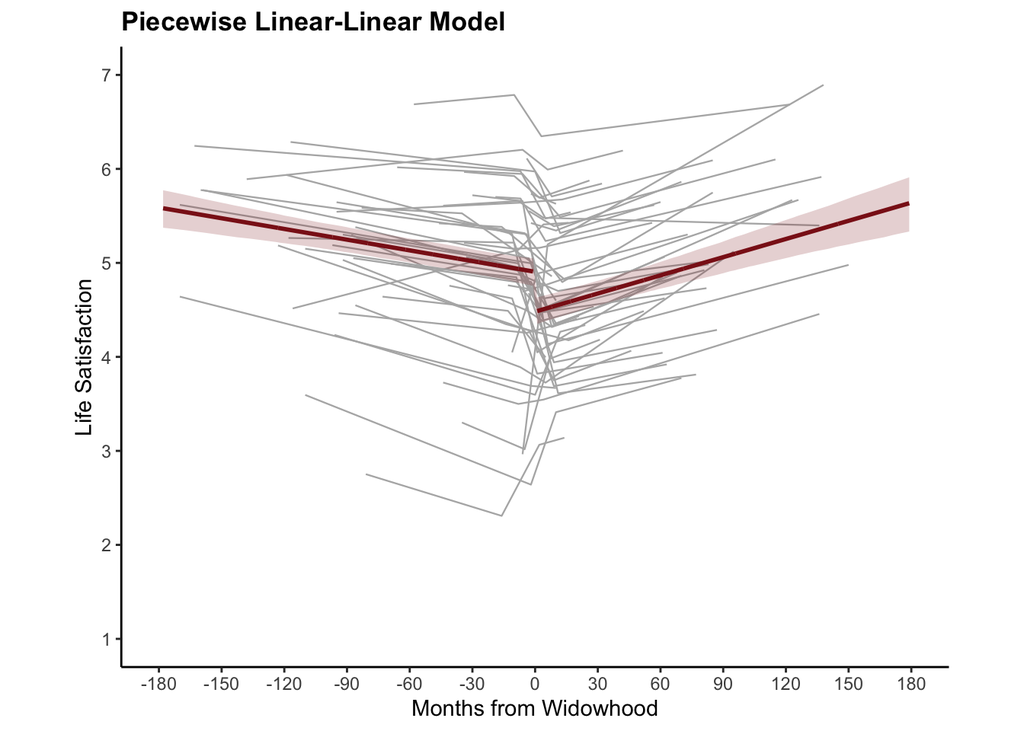

```r
# Create the plot using the pre-configured plot base
plot_base +
  geom_line(
    data = wido_rsample,
    aes(mnths, lifesatisfaction_pw_r, group = id),
    color = "grey70",
    linewidth = 0.4
  ) +
  geom_line(
    data = wido,
    aes(
      x = mnths,
      y = ifelse(mnths == 0, NA, lifesatisfaction_pw_f)
      ),
    color = "firebrick4",
    linewidth = 1
  ) +
  geom_ribbon(
    data = wido %>% filter(mnths != 0),
    aes(ymin = lower_bound, ymax = upper_bound, x = mnths),
    alpha = 0.2,
    fill = "firebrick4"
  ) +
  ggtitle("Piecewise Linear-Linear Model") +
  theme(plot.title = element_text(size = 13, face = "bold"))
```

## Model Performance

### Evaluating the Model

Assess the model’s performance using the Bayesian Information Criterion (BIC), R-squared (R²), Mean Absolute Error (MAE), and Root Mean Squared Error (RMSE).

```r
# Compute BIC for the fitted model
round(BIC(pw), 2)
```

```
[1] 5356.08
```

```r
# Calculate R², MAE, and RMSE for the fixed effects predictions
data.frame(
  R2_FE = round(R2(wido$lifesatisfaction_pw_f, wido$m_lifesat_per_mnth), 2),
  MAE_FE = round(MAE(wido$lifesatisfaction_pw_f, wido$m_lifesat_per_mnth), 2),
  RMSE_FE = round(RMSE(wido$lifesatisfaction_pw_f, wido$m_lifesat_per_mnth), 2)
)
```

```
  R2_FE MAE_FE RMSE_FE
1  0.27   0.29    0.39
```

```r
# Calculate R², MAE, and RMSE for the random effects predictions
data.frame(
  R2_RE = round(R2(wido$lifesatisfaction_pw_r, wido$lifesatisfaction), 2),
  MAE_RE = round(MAE(wido$lifesatisfaction_pw_r, wido$lifesatisfaction), 2),
  RMSE_RE = round(RMSE(wido$lifesatisfaction_pw_r, wido$lifesatisfaction), 2)
)
```

```
  R2_RE MAE_RE RMSE_RE
1  0.77    0.4    0.53
```

### Cross-Validation

To assess the replicability of the model, perform cross-validation using the training and test datasets. For each training dataset, fit the model and compute performance metrics for the associated test dataset R², MAE, and RMSE.

```r
# Initialise vectors to store performance metrics
R2_values <- c()
MAE_values <- c()
RMSE_values <- c()

# Perform cross-validation
for (i in 1:length(training_datasets)) {
  # Get the current training and test dataset
  training_data <- training_datasets[[i]]
  test_data <- test_datasets[[i]]

  # Create time variables
  training_data <- training_data %>%
  mutate(postD = if_else(mnths <= 0, 0, 1),
         preLin = if_else(mnths <= 0, mnths, 0),
         postLin = if_else(mnths <= 0, 0, mnths))

  test_data <- test_data %>%
  mutate(postD = if_else(mnths <= 0, 0, 1),
         preLin = if_else(mnths <= 0, mnths, 0),
         postLin = if_else(mnths <= 0, 0, mnths))

  # Standardise preLin and postLin
  training_data$preLin_s <- scale(training_data$preLin)
  training_data$postLin_s <- scale(training_data$postLin)

  test_data$preLin_s <- scale(test_data$preLin)
  test_data$postLin_s <- scale(test_data$postLin)

  # Fit the model
  pw <- lmer(
    lifesatisfaction ~ postD + preLin_s + postLin_s +
      (postD + preLin_s + postLin_s | id),
    data = training_data)

  # Predict fixed effects
  test_predictions <- predict(pw, test_data, re.form = NA)

  # Compute average test trajectory
  test_data <- test_data %>%
    group_by(mnths) %>%
    mutate(m_lifesat_per_mnth = mean(lifesatisfaction, na.rm = TRUE))

  # Calculate performance metrics
  R2_values <- c(R2_values, R2(test_predictions, test_data$m_lifesat_per_mnth))
  MAE_values <- c(MAE_values, MAE(test_predictions, test_data$m_lifesat_per_mnth))
  RMSE_values <- c(RMSE_values, RMSE(test_predictions, test_data$m_lifesat_per_mnth))
}

# Compute average performance metrics (mean)
  average_R2 <- mean(R2_values)
  average_MAE <- mean(MAE_values)
  average_RMSE <- mean(RMSE_values)

# Compute average performance metrics (SD)
  sd_R2 <- sd(R2_values)
  sd_MAE <- sd(MAE_values)
  sd_RMSE <- sd(RMSE_values)

# Combine the mean and standard deviation into one data.frame
combined_metrics <- data.frame(
  Metric = c("R²", "MAE", "RMSE"),
  Mean = round(c(average_R2, average_MAE, average_RMSE), 2),
  SD = round(c(sd_R2, sd_MAE, sd_RMSE), 2)
)

# Print the combined metrics
print(combined_metrics)
```

```
  Metric Mean   SD
1     R² 0.10 0.07
2    MAE 0.58 0.08
3   RMSE 0.76 0.13
```